# Codebook for data

Autogenerated data summary from dataMaid

2018-12-04 15:18:00

# Data report overview

The dataset examined has the following dimensions:

| Feature | Result |
| --- | --- |
| Number of observations | 1470 |
| Number of variables | 32 |

# Codebook summary table

| Label | Variable | Class | # unique values | Missing | Description |
| --- | --- | --- | --- | --- | --- |
|  | **Age** | integer | 43 | 0.00 % |  |
|  | **Attrition** | integer | 2 | 0.00 % |  |
|  | **BusTravel** | factor | 3 | 0.00 % |  |
|  | **DailyRate** | integer | 886 | 0.00 % |  |
|  | **Department** | factor | 3 | 0.00 % |  |
|  | **HomeDist** | integer | 29 | 0.00 % |  |
|  | **Education** | integer | 5 | 0.00 % |  |
|  | **EducField** | factor | 6 | 0.00 % |  |
|  | **EnviroSat** | integer | 4 | 0.00 % |  |
|  | **Gender** | factor | 2 | 0.00 % |  |
|  | **HourlyRate** | integer | 71 | 0.00 % |  |
|  | **JobInvolv** | integer | 4 | 0.00 % |  |
|  | **JobLevel** | integer | 5 | 0.00 % |  |
|  | **JobRole** | character | 9 | 0.00 % |  |
|  | **JobSat** | integer | 4 | 0.00 % |  |
|  | **MaritalStat** | character | 3 | 0.00 % |  |
|  | **MthlyInc** | integer | 1349 | 0.00 % |  |
|  | **MonthlyRate** | integer | 1427 | 0.00 % |  |
|  | **NumCompWrk** | integer | 10 | 0.00 % |  |
|  | **OverTime** | character | 2 | 0.00 % |  |
|  | **PercSalInc** | integer | 15 | 0.00 % |  |
|  | **PerfRating** | integer | 2 | 0.00 % |  |
|  | **RelationSat** | integer | 4 | 0.00 % |  |
|  | **StkOptLevel** | integer | 4 | 0.00 % |  |
|  | **TotWrkYrs** | integer | 40 | 0.00 % |  |
|  | **TrnTmsLstYr** | integer | 7 | 0.00 % |  |
|  | **WrkLifeBal** | integer | 4 | 0.00 % |  |
|  | **YrsAtComp** | integer | 37 | 0.00 % |  |
|  | **YrsCurrRole** | integer | 19 | 0.00 % |  |
|  | **YrsLstProm** | integer | 16 | 0.00 % |  |
|  | **YrsCurrMgr** | integer | 18 | 0.00 % |  |
|  | **LifeSat** | integer | 10 | 0.00 % |  |

# Variable list

## Age

| Feature | Result |
| --- | --- |
| Variable type | integer |
| Number of missing obs. | 0 (0 %) |
| Number of unique values | 43 |
| Median | 36 |
| 1st and 3rd quartiles | 30; 43 |
| Min. and max. | 18; 60 |

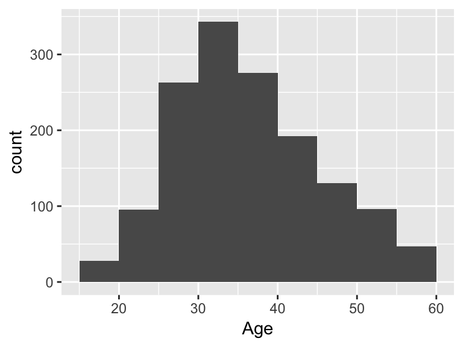

## Attrition

| Feature | Result |
| --- | --- |
| Variable type | integer |
| Number of missing obs. | 0 (0 %) |
| Number of unique values | 2 |
| Median | 0 |
| 1st and 3rd quartiles | 0; 0 |
| Min. and max. | 0; 1 |

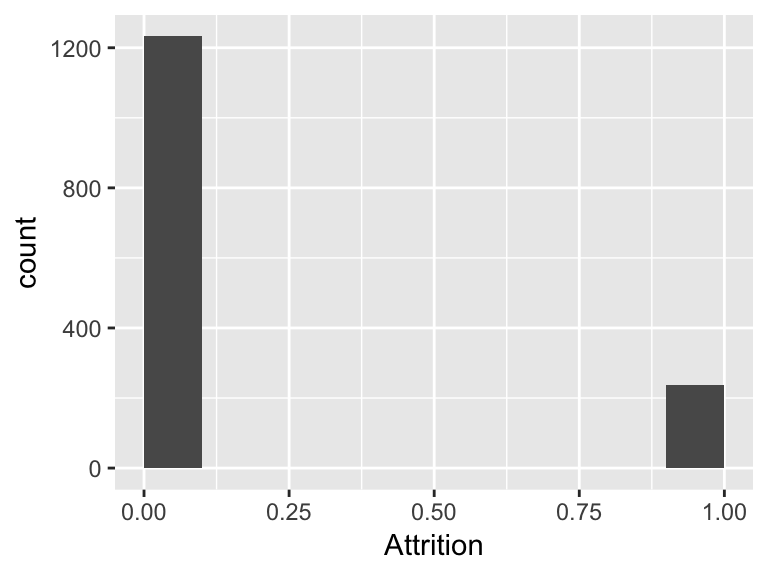

## BusTravel

| Feature | Result |
| --- | --- |
| Variable type | factor |
| Number of missing obs. | 0 (0 %) |
| Number of unique values | 3 |
| Mode | “Travel_Rarely” |
| Reference category | Non-Travel |

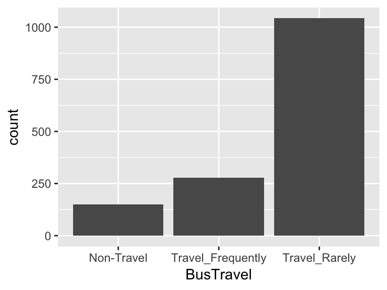

- Observed factor levels: "Non-Travel", "Travel_Frequently", "Travel_Rarely".

## DailyRate

| Feature | Result |
| --- | --- |
| Variable type | integer |
| Number of missing obs. | 0 (0 %) |
| Number of unique values | 886 |
| Median | 802 |
| 1st and 3rd quartiles | 465; 1157 |
| Min. and max. | 102; 1499 |

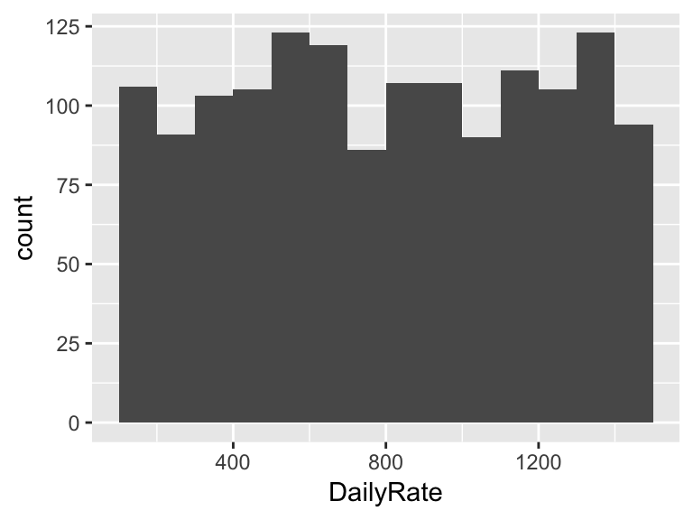

## Department

| Feature | Result |
| --- | --- |
| Variable type | factor |
| Number of missing obs. | 0 (0 %) |
| Number of unique values | 3 |
| Mode | “Research & Development” |
| Reference category | Human Resources |

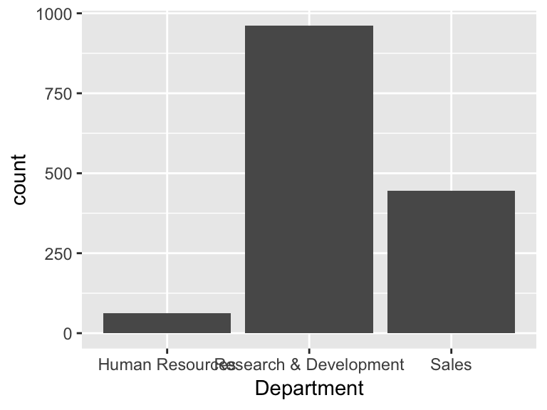

- Observed factor levels: "Human Resources", "Research & Development", "Sales".

## HomeDist

| Feature | Result |
| --- | --- |
| Variable type | integer |
| Number of missing obs. | 0 (0 %) |
| Number of unique values | 29 |
| Median | 7 |
| 1st and 3rd quartiles | 2; 14 |
| Min. and max. | 1; 29 |

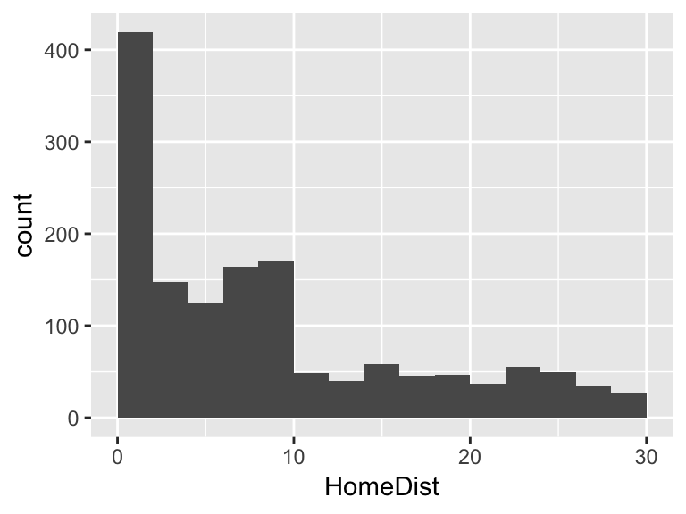

## Education

| Feature | Result |
| --- | --- |
| Variable type | integer |
| Number of missing obs. | 0 (0 %) |
| Number of unique values | 5 |
| Median | 3 |
| 1st and 3rd quartiles | 2; 4 |
| Min. and max. | 1; 5 |

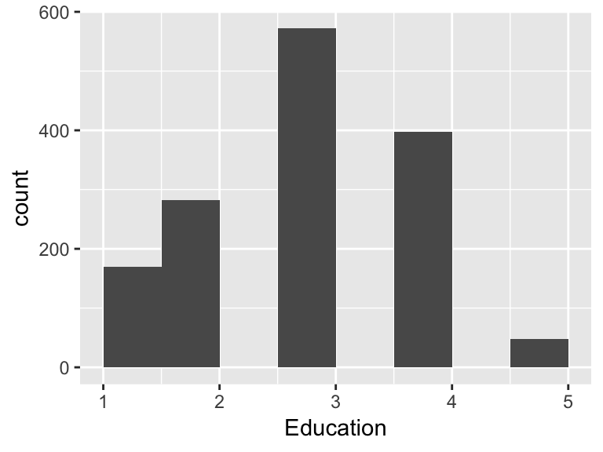

## EducField

| Feature | Result |
| --- | --- |
| Variable type | factor |
| Number of missing obs. | 0 (0 %) |
| Number of unique values | 6 |
| Mode | “Life Sciences” |
| Reference category | Human Resources |

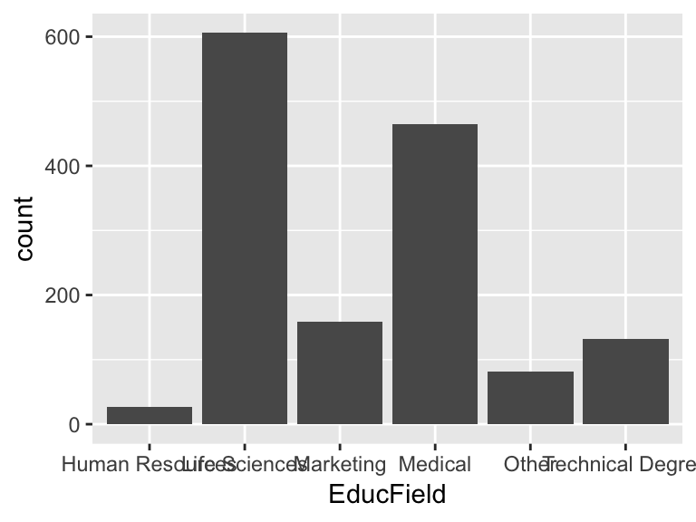

- Observed factor levels: "Human Resources", "Life Sciences", "Marketing", "Medical", "Other", "Technical Degree".

## EnviroSat

| Feature | Result |
| --- | --- |
| Variable type | integer |
| Number of missing obs. | 0 (0 %) |
| Number of unique values | 4 |
| Median | 3 |
| 1st and 3rd quartiles | 2; 4 |
| Min. and max. | 1; 4 |

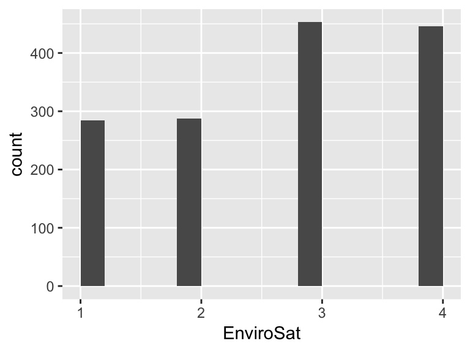

## Gender

| Feature | Result |
| --- | --- |
| Variable type | factor |
| Number of missing obs. | 0 (0 %) |
| Number of unique values | 2 |
| Mode | “Male” |
| Reference category | Female |

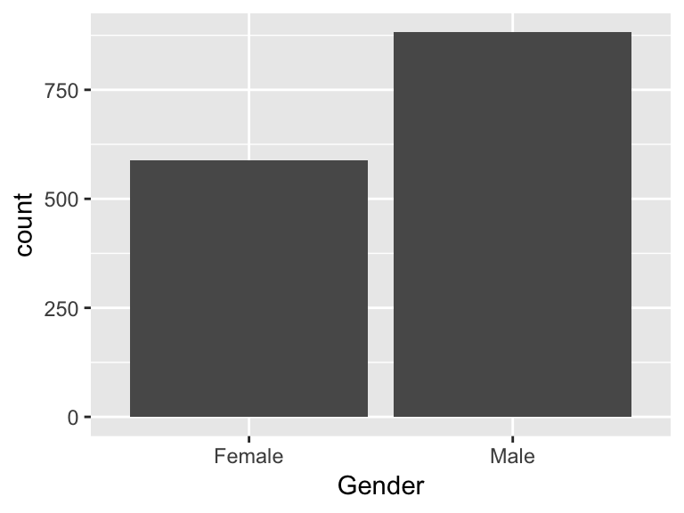

- Observed factor levels: "Female", "Male".

## HourlyRate

| Feature | Result |
| --- | --- |
| Variable type | integer |
| Number of missing obs. | 0 (0 %) |
| Number of unique values | 71 |
| Median | 66 |
| 1st and 3rd quartiles | 48; 83.75 |
| Min. and max. | 30; 100 |

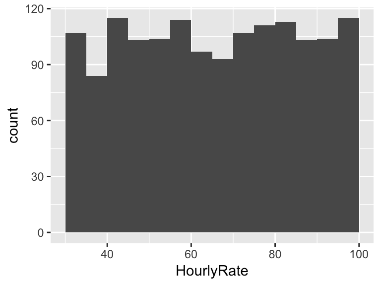

## JobInvolv

| Feature | Result |
| --- | --- |
| Variable type | integer |
| Number of missing obs. | 0 (0 %) |
| Number of unique values | 4 |
| Median | 3 |
| 1st and 3rd quartiles | 2; 3 |
| Min. and max. | 1; 4 |

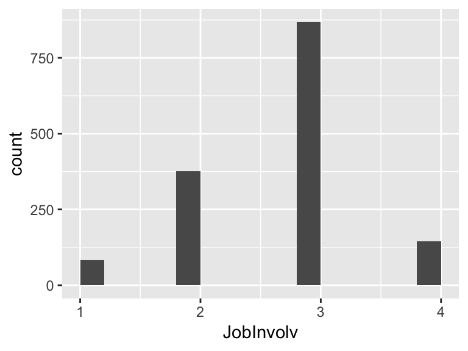

## JobLevel

| Feature | Result |
| --- | --- |
| Variable type | integer |
| Number of missing obs. | 0 (0 %) |
| Number of unique values | 5 |
| Median | 2 |
| 1st and 3rd quartiles | 1; 3 |
| Min. and max. | 1; 5 |

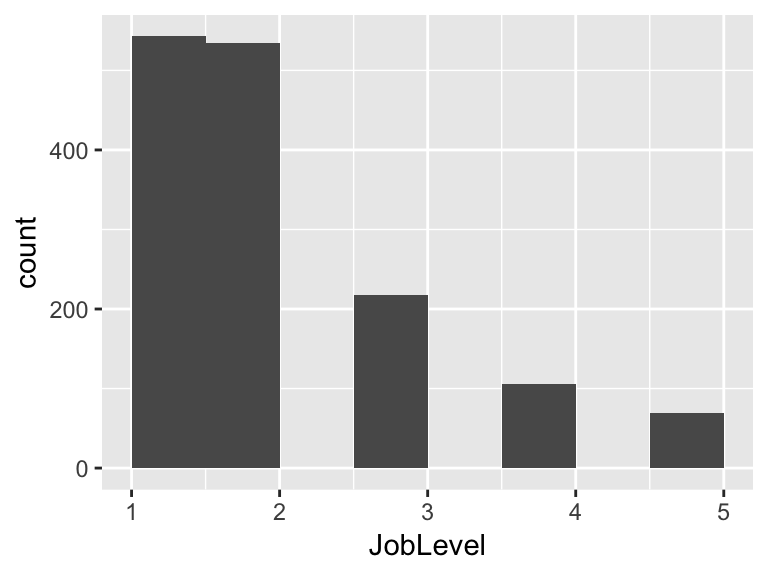

## JobRole

| Feature | Result |
| --- | --- |
| Variable type | character |
| Number of missing obs. | 0 (0 %) |
| Number of unique values | 9 |
| Mode | “SalesExecutive” |

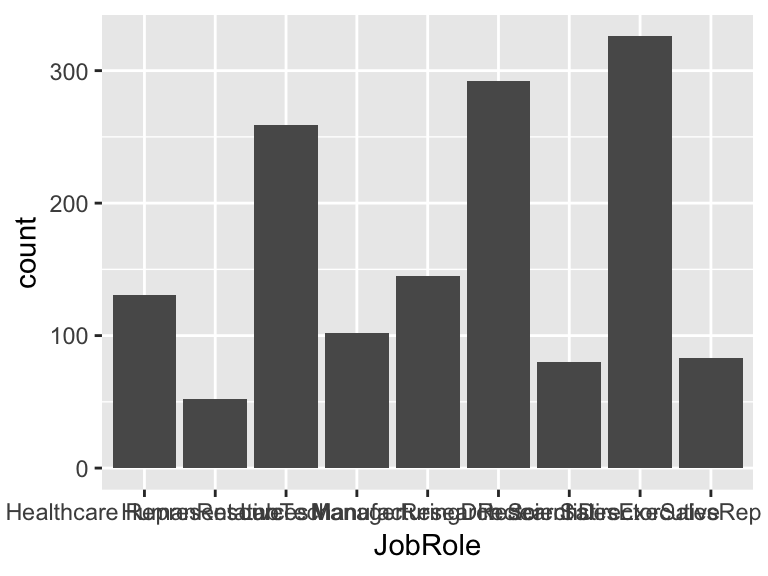

- Observed factor levels: "Healthcare Representative", "HumanResources", "LabTech", "Manager", "ManufacturingDirector", "Research Scientist", "ResearchDirector", "SalesExecutive", "SalesRep".

## JobSat

| Feature | Result |
| --- | --- |
| Variable type | integer |
| Number of missing obs. | 0 (0 %) |
| Number of unique values | 4 |
| Median | 3 |
| 1st and 3rd quartiles | 2; 4 |
| Min. and max. | 1; 4 |

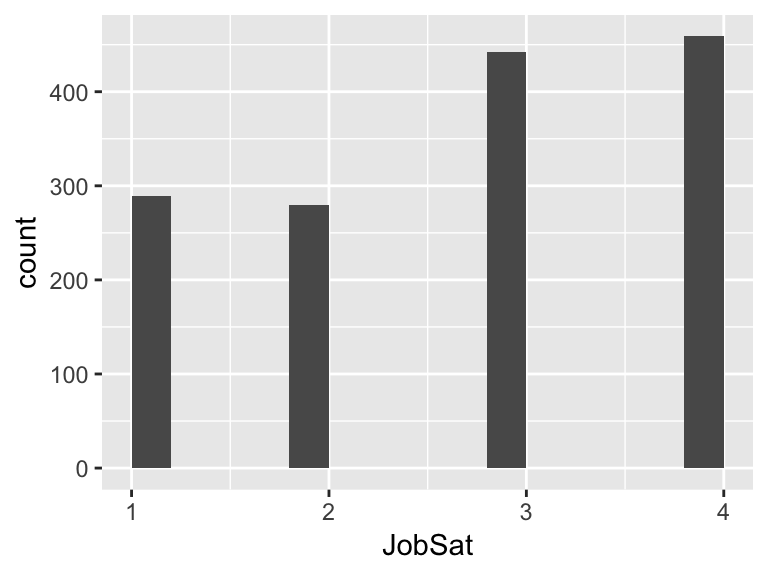

## MaritalStat

| Feature | Result |
| --- | --- |
| Variable type | character |
| Number of missing obs. | 0 (0 %) |
| Number of unique values | 3 |
| Mode | “1” |

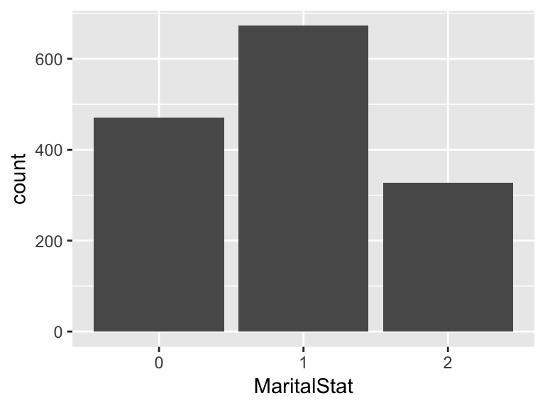

- Observed factor levels: "0", "1", "2".

## MthlyInc

| Feature | Result |
| --- | --- |
| Variable type | integer |
| Number of missing obs. | 0 (0 %) |
| Number of unique values | 1349 |
| Median | 4919 |
| 1st and 3rd quartiles | 2911; 8379 |
| Min. and max. | 1009; 19999 |

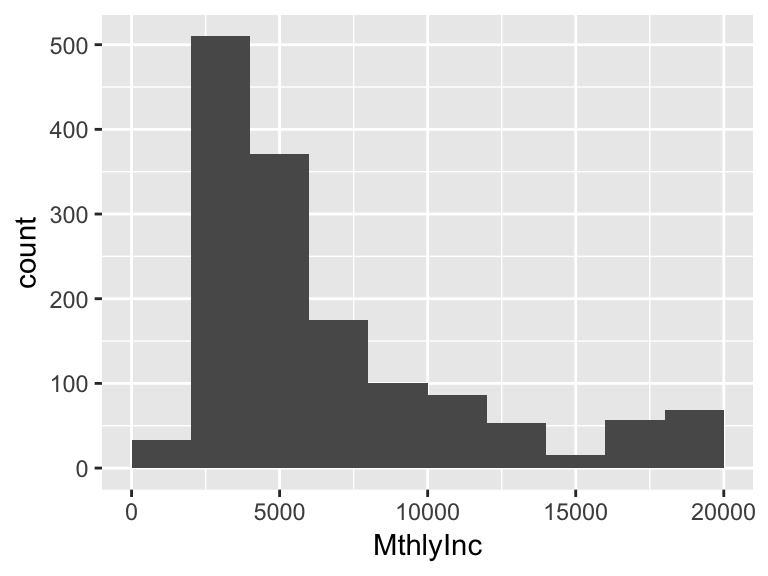

## MonthlyRate

| Feature | Result |
| --- | --- |
| Variable type | integer |
| Number of missing obs. | 0 (0 %) |
| Number of unique values | 1427 |
| Median | 14235.5 |
| 1st and 3rd quartiles | 8047; 20461.5 |
| Min. and max. | 2094; 26999 |

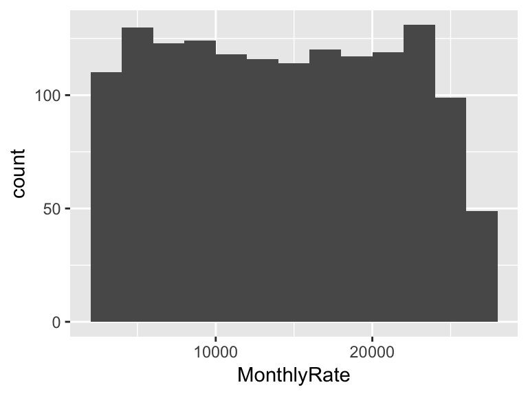

## NumCompWrk

| Feature | Result |
| --- | --- |
| Variable type | integer |
| Number of missing obs. | 0 (0 %) |
| Number of unique values | 10 |
| Median | 2 |
| 1st and 3rd quartiles | 1; 4 |
| Min. and max. | 0; 9 |

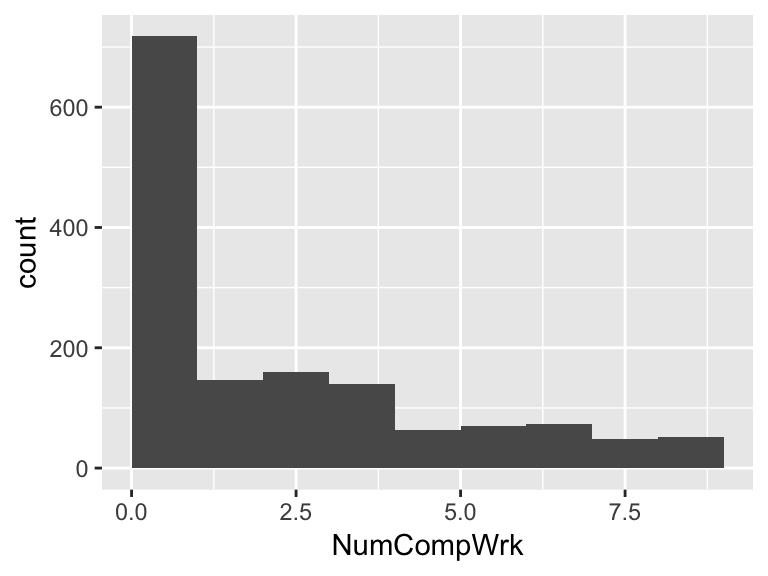

## OverTime

| Feature | Result |
| --- | --- |
| Variable type | character |
| Number of missing obs. | 0 (0 %) |
| Number of unique values | 2 |
| Mode | “0” |

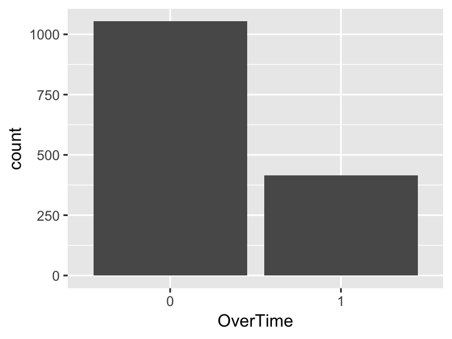

- Observed factor levels: "0", "1".

## PercSalInc

| Feature | Result |
| --- | --- |
| Variable type | integer |
| Number of missing obs. | 0 (0 %) |
| Number of unique values | 15 |
| Median | 14 |
| 1st and 3rd quartiles | 12; 18 |
| Min. and max. | 11; 25 |

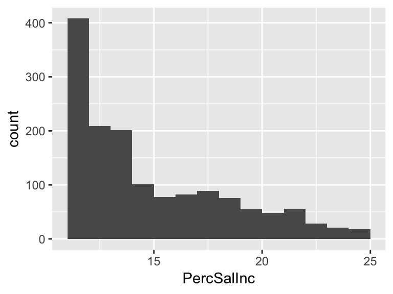

## PerfRating

| Feature | Result |
| --- | --- |
| Variable type | integer |
| Number of missing obs. | 0 (0 %) |
| Number of unique values | 2 |
| Median | 3 |
| 1st and 3rd quartiles | 3; 3 |
| Min. and max. | 3; 4 |

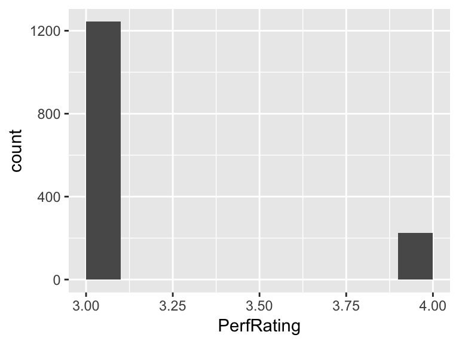

## RelationSat

| Feature | Result |
| --- | --- |
| Variable type | integer |
| Number of missing obs. | 0 (0 %) |
| Number of unique values | 4 |
| Median | 3 |
| 1st and 3rd quartiles | 2; 4 |
| Min. and max. | 1; 4 |

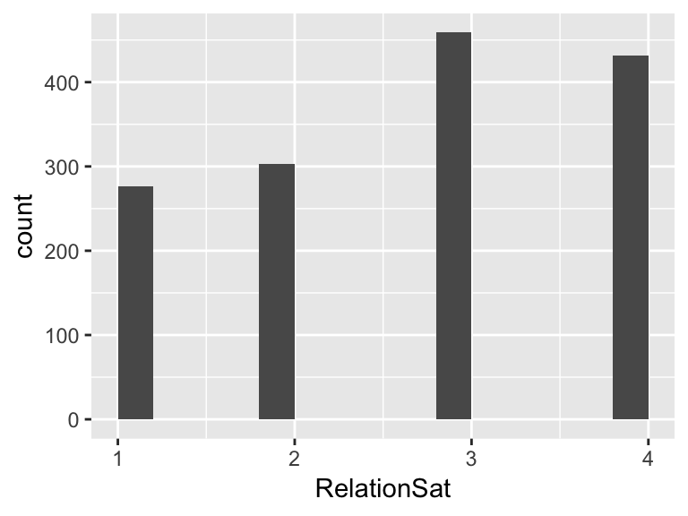

## StkOptLevel

| Feature | Result |
| --- | --- |
| Variable type | integer |
| Number of missing obs. | 0 (0 %) |
| Number of unique values | 4 |
| Median | 1 |
| 1st and 3rd quartiles | 0; 1 |
| Min. and max. | 0; 3 |

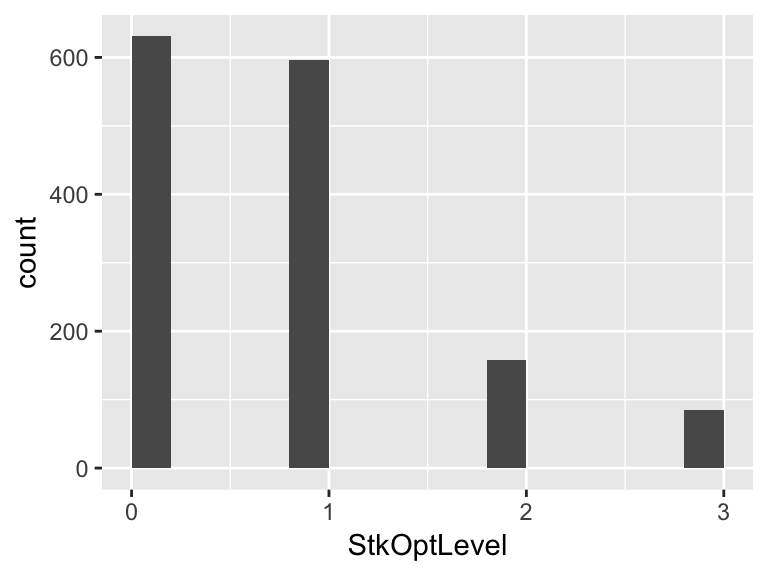

## TotWrkYrs

| Feature | Result |
| --- | --- |
| Variable type | integer |
| Number of missing obs. | 0 (0 %) |
| Number of unique values | 40 |
| Median | 10 |
| 1st and 3rd quartiles | 6; 15 |
| Min. and max. | 0; 40 |

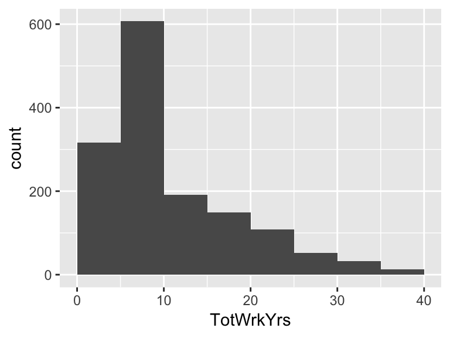

## TrnTmsLstYr

| Feature | Result |
| --- | --- |
| Variable type | integer |
| Number of missing obs. | 0 (0 %) |
| Number of unique values | 7 |
| Median | 3 |
| 1st and 3rd quartiles | 2; 3 |
| Min. and max. | 0; 6 |

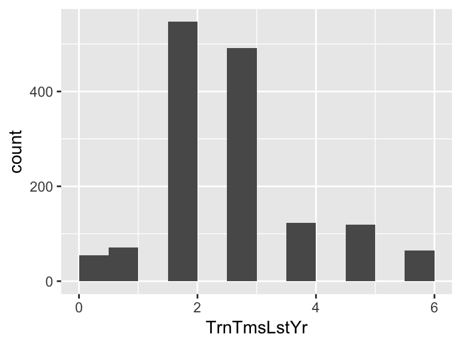

## WrkLifeBal

| Feature | Result |
| --- | --- |
| Variable type | integer |
| Number of missing obs. | 0 (0 %) |
| Number of unique values | 4 |
| Median | 3 |
| 1st and 3rd quartiles | 2; 3 |
| Min. and max. | 1; 4 |

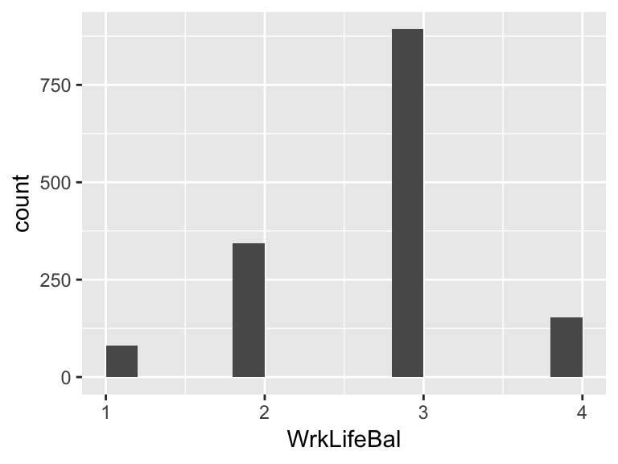

## YrsAtComp

| Feature | Result |
| --- | --- |
| Variable type | integer |
| Number of missing obs. | 0 (0 %) |
| Number of unique values | 37 |
| Median | 5 |
| 1st and 3rd quartiles | 3; 9 |
| Min. and max. | 0; 40 |

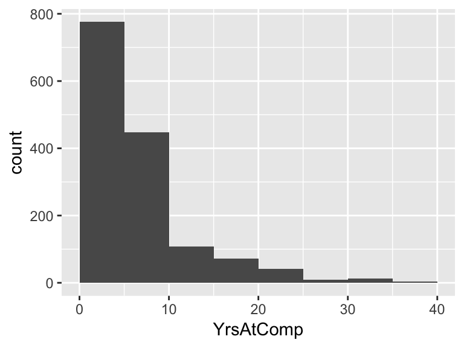

## YrsCurrRole

| Feature | Result |
| --- | --- |
| Variable type | integer |
| Number of missing obs. | 0 (0 %) |
| Number of unique values | 19 |
| Median | 3 |
| 1st and 3rd quartiles | 2; 7 |
| Min. and max. | 0; 18 |

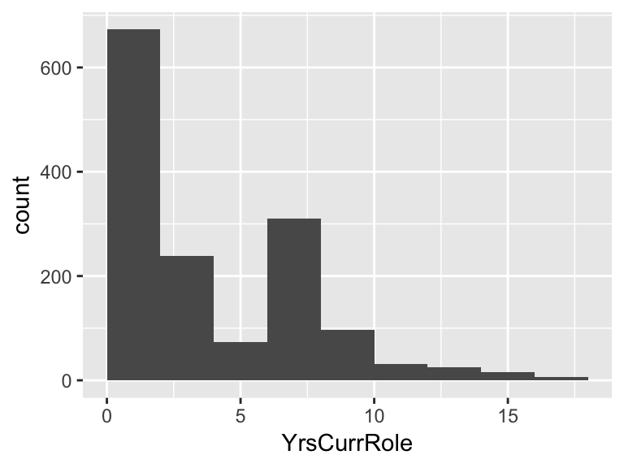

## YrsLstProm

| Feature | Result |
| --- | --- |
| Variable type | integer |
| Number of missing obs. | 0 (0 %) |
| Number of unique values | 16 |
| Median | 1 |
| 1st and 3rd quartiles | 0; 3 |
| Min. and max. | 0; 15 |

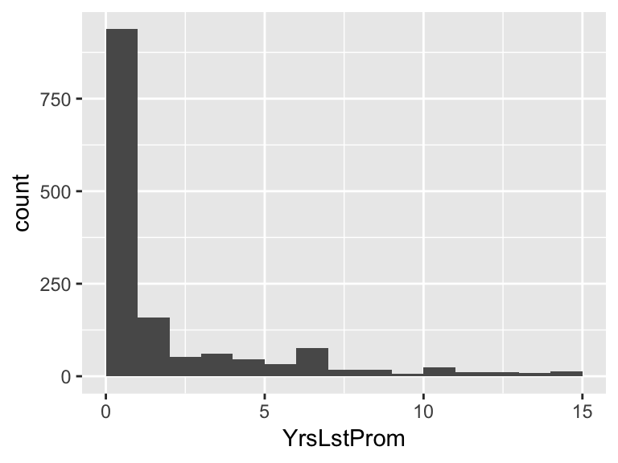

## YrsCurrMgr

| Feature | Result |
| --- | --- |
| Variable type | integer |
| Number of missing obs. | 0 (0 %) |
| Number of unique values | 18 |
| Median | 3 |
| 1st and 3rd quartiles | 2; 7 |
| Min. and max. | 0; 17 |

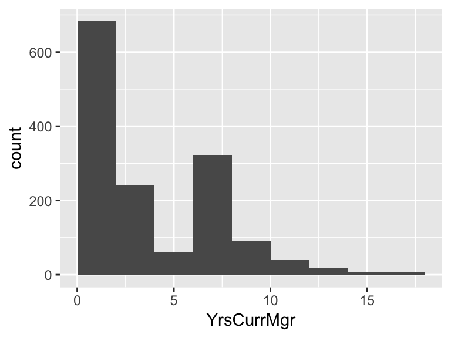

## LifeSat

| Feature | Result |
| --- | --- |
| Variable type | integer |
| Number of missing obs. | 0 (0 %) |
| Number of unique values | 10 |
| Median | 8 |
| 1st and 3rd quartiles | 7; 10 |
| Min. and max. | 3; 12 |

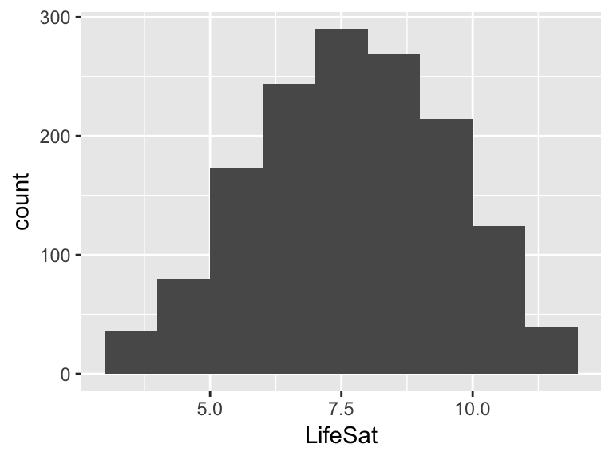

Report generation information:

- Created by Adam Scheerer (username: `AdamScheerer`).
- Report creation time: Tue Dec 04 2018 15:18:01
- Report was run from directory: `/Users/AdamScheerer/Desktop/CaseStudyTwo`
- dataMaid v1.2.0 [Pkg: 2018-10-03 from CRAN (R 3.5.0)]
- R version 3.5.1 (2018-07-02).
- Platform: x86_64-apple-darwin15.6.0 (64-bit)(OS X El Capitan 10.11.3).
- Function call: `makeDataReport(data = data, mode = c("summarize", "visualize", "check"), smartNum = FALSE, file = "codebook_data.Rmd", checks = list( character = "showAllFactorLevels", factor = "showAllFactorLevels", labelled = "showAllFactorLevels", haven_labelled = "showAllFactorLevels", numeric = NULL, integer = NULL, logical = NULL, Date = NULL), listChecks = FALSE, maxProbVals = Inf, codebook = TRUE, reportTitle = "Codebook for data")`